# Mv_Lab_1

Kim Youngrae

2016년 9월 26일

# Content

- 함수 ‘svd’
- 표본 공분산 행렬
- 예제 4.15
- 화살촉 행렬의 역행렬

# Function ‘svd’

저번 선형대수학 Review 시간에 Singular value decomposition에 대해 확인했다. SVD를 R로 계산하는 방법을 알아보자.

#### Singular Value Decomposition

> $X=UDV^T$, where $U^tU=I, VV^t=I, V^tV=I$.

먼저 이번에 사용할 Data matrix는 다음과 같다. (예제 4.15에서 사용하는 자료에서 가져온 행렬임. 앞부분은 자료를 입력하는 과정입니다.)

```r
set.seed(1)
data<-read.table("/users/kyr0302/Desktop/lab_1/T4-3.dat")
colnames(data)<-c("x1","x2","x3","x4","dsq")
X<-data[,-5]
```

```r
head(X)
```

```
##     x1   x2   x3   x4
## 1 1889 1651 1561 1778
## 2 2403 2048 2087 2197
## 3 2119 1700 1815 2222
## 4 1645 1627 1110 1533
## 5 1976 1916 1614 1883
## 6 1712 1712 1439 1546
```

```r
str(X)
```

```
## 'data.frame':    30 obs. of  4 variables:
##  $ x1: int  1889 2403 2119 1645 1976 1712 1943 2104 2983 1745 ...
##  $ x2: int  1651 2048 1700 1627 1916 1712 1685 1820 2794 1600 ...
##  $ x3: int  1561 2087 1815 1110 1614 1439 1271 1717 2412 1384 ...
##  $ x4: int  1778 2197 2222 1533 1883 1546 1671 1874 2581 1508 ...
```

Singular value decomposition을 하기 위해 R의 기본 패키지에 내장되어 있는 svd 함수를 이용한다.

svd 함수는 3가지 값을 받는 함수이다. ; svd(X,nu,nv)

- X : Singular value decomposition을 할 행렬
- nu : 계산할 left singluar vector의 개수
- nv : 계산할 right singular vector의 개수

여기서 nu와 nv는 생략이 가능하며, 생략한 경우에는 최대값을 선택하게 된다. (n과 p중 작은 값)

```r
svd(X)
```

```
## $d
## [1] 19207.2896   891.3164   479.6624   403.3639
##
## $u
##             [,1]         [,2]         [,3]        [,4]
##  [1,] -0.1794313 -0.133950592 -0.014983937 -0.03662399
##  [2,] -0.2275023 -0.229517208  0.196876011 -0.19252908
##  [3,] -0.2046479 -0.430714071 -0.243120340  0.01449953
##  [4,] -0.1551558  0.174070463 -0.315210952  0.21154021
##  [5,] -0.1928405  0.005369494  0.001456708  0.20895185
##  [6,] -0.1671501  0.071303808  0.186511610  0.14392045
##  [7,] -0.1724848  0.119283570 -0.364300990 -0.16777604
##  [8,] -0.1960967 -0.093087005  0.066779143 -0.17267167
##  [9,] -0.2811638  0.089954307  0.232622643 -0.07384310
## [10,] -0.1629065  0.041087865  0.082033472 -0.08087223
```

[output cut: 27 more lines]

결과를 보면, 3가지의 결과를 주는데, $d 가 SVD 결과의 $D$ 행렬이다. $D$ 행렬은 대각행렬이므로, 행렬이 아닌 대각원소를 모은 Vector로 표현되어 있다. $u, $v는 각각 $U, V$ 행렬을 나타낸다.

# 표본 공분산 행렬

이번에는 표본 공분산 행렬을 실제로 계산해보고, 실제 공분산행렬과 얼마나 닮았는지 확인해보도록 한다.

먼저 임의의 10차원 정규분포에서 크기가 100인 표본을 생성해보자. mvtnorm 패키지의 rmvnorm 함수를 이용하면 다변량정규분포의 난수를 생성할 수 있다. (아래의 B는 제가 임의로 만든 공분산행렬입니다. 여기에서는 True Covariance Matrix로 사용됩니다.)

```r
library(mvtnorm)
A<-rmvnorm(10,mean=rep(0,10),sigma=diag(10))
B<-cov(A)
```

```r
tv<-B
A<-rmvnorm(100,mean=rep(0,10),sigma=tv)
scv<-cov(A)
```

두개의 행렬을 비교해보면 다음과 같다.

```r
head(tv)
```

```
##             [,1]        [,2]        [,3]        [,4]        [,5]
## [1,]  1.05560621 -0.05842426 -0.11699417 -0.45748113 -0.39358257
## [2,] -0.05842426  0.35322336 -0.02695757  0.05511919  0.34031872
## [3,] -0.11699417 -0.02695757  0.45214710  0.01900167 -0.08763972
## [4,] -0.45748113  0.05511919  0.01900167  1.57951058 -0.32923852
## [5,] -0.39358257  0.34031872 -0.08763972 -0.32923852  1.21257251
## [6,]  0.01775761 -0.09777611  0.17752844 -0.38217259  0.43408000
##             [,6]        [,7]       [,8]        [,9]       [,10]
## [1,]  0.01775761 -0.48439236  0.3059833  0.23155099  0.61102273
## [2,] -0.09777611 -0.10945085 -0.1043429 -0.23342603 -0.02741523
## [3,]  0.17752844 -0.13788750 -0.1488944 -0.22216339  0.04024746
## [4,] -0.38217259 -0.18338150  0.4396477 -0.14249444 -0.04170400
## [5,]  0.43408000  0.08086654 -0.4230257 -0.22610957 -0.34189882
## [6,]  0.62725969 -0.18981054 -0.3731002 -0.05369386 -0.15712801
```

```r
head(scv)
```

```
##             [,1]        [,2]        [,3]        [,4]       [,5]
## [1,]  1.28742534 -0.02303276 -0.04014905 -0.57288533 -0.4202720
## [2,] -0.02303276  0.42962475 -0.09430273 -0.08634186  0.5073453
## [3,] -0.04014905 -0.09430273  0.48912541 -0.07033291 -0.1333585
## [4,] -0.57288533 -0.08634186 -0.07033291  1.63426746 -0.5066543
## [5,] -0.42027199  0.50734527 -0.13335851 -0.50665430  1.7299624
## [6,]  0.08679564 -0.05579397  0.23075417 -0.54648524  0.7528606
##             [,6]       [,7]        [,8]        [,9]       [,10]
## [1,]  0.08679564 -0.6876198  0.34541172  0.18996009  0.74610839
## [2,] -0.05579397 -0.1405558 -0.15004558 -0.26716388 -0.08317127
## [3,]  0.23075417 -0.1755949 -0.09387987 -0.23769207  0.10832570
## [4,] -0.54648524  0.1055176  0.59821800  0.06709879 -0.04962465
## [5,]  0.75286056 -0.1614295 -0.66905329 -0.44200404 -0.59636174
## [6,]  0.94356085 -0.4277576 -0.49295631 -0.20156168 -0.22518805
```

두 행렬의 Eigenvalue들과, 첫번째 Eigenvector의 관계를 살펴보면 다음과 같다. eigenvector를 잘 찾아낸다는 사실은 두 vector의 방향이 같으면 되는것이므로, 두 vector를 내적하여 값이 1 또는 -1과 가까운지 알아보면 된다.

```r
eigen(scv)$values
```

```
##  [1]  3.577990e+00  2.635476e+00  1.310882e+00  9.235541e-01  6.258601e-01
##  [6]  3.622839e-01  1.721576e-01  5.625771e-02  6.165714e-04 -6.339545e-17
```

```r
eigen(tv)$values
```

```
##  [1] 2.593671e+00 2.087804e+00 1.224664e+00 8.448809e-01 5.393664e-01
##  [6] 4.027531e-01 2.138221e-01 6.824823e-02 5.913877e-04 8.146188e-17
```

```r
abs(t(eigen(scv)$vectors[,1])%*%eigen(tv)$vectors[,1])
```

```
##           [,1]
## [1,] 0.9484888
```

##### 500번의 반복

실제로 잘 들어맞는지 확인하기 위해, 위와 같은 과정을 500번 반복하여, 표본 공분산행렬의 eigenvalue와 eigenvector가 실제 공분산행렬의 것들과 같은지 비교해본다.

```r
theta<-rep(0,500)
evl<-matrix(0,nrow=500,ncol=5);
eig.res.tr<-eigen(tv)
for(i in 1:500){
A<-rmvnorm(100,mean=rep(0,10),sigma=tv)
scv<-cov(A)
eig.res<-eigen(scv)
theta[i]<-abs(t(eig.res$vectors[,1])%*%eig.res.tr$vectors[,1])
evl[i,]<-eig.res$values[1:5]
}
```

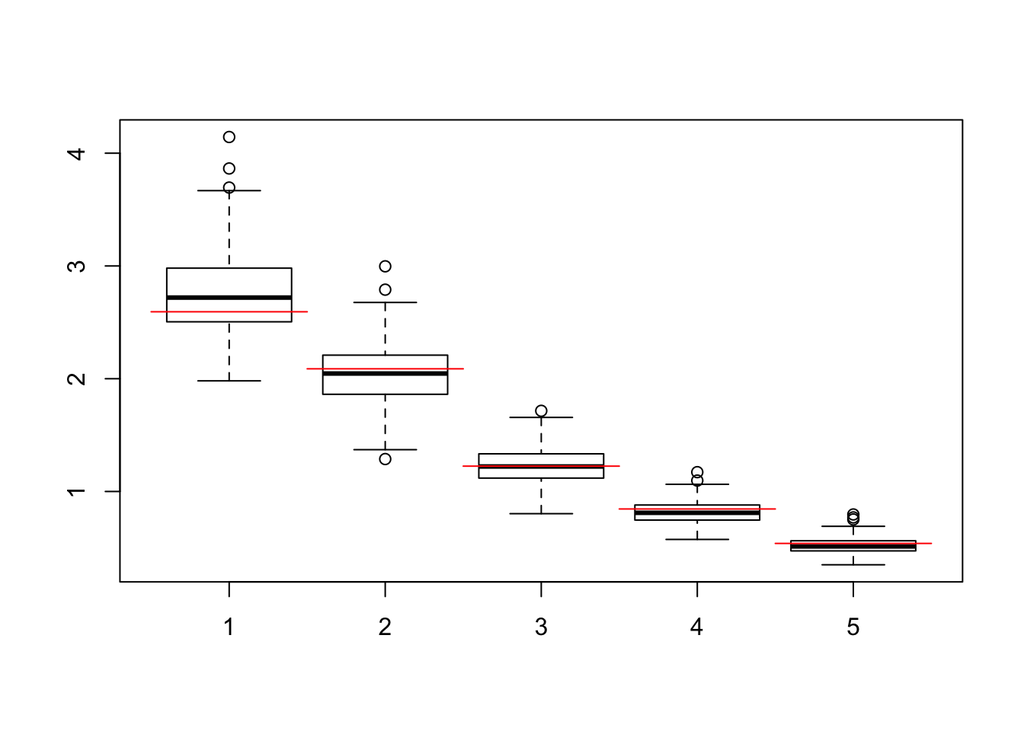

```r
boxplot(evl)
x0s <- 1:5 - 0.5
x1s <- 1:5 + 0.5
y0s <- eig.res.tr$values[1:5]
segments(x0 = x0s, x1 = x1s, y0 = y0s, col = "red")
```

500번의 반복시행에서 구해진 5개의 Eigenvalue들을 Boxplot으로 나타낸 것이다. 여기서 빨간 선은 우리가 참값으로 결정한 공분산행렬의 Eigenvalue들이다. 대략적으로 빨간 선 주변에서 분포하고 있음을 알 수 있다.

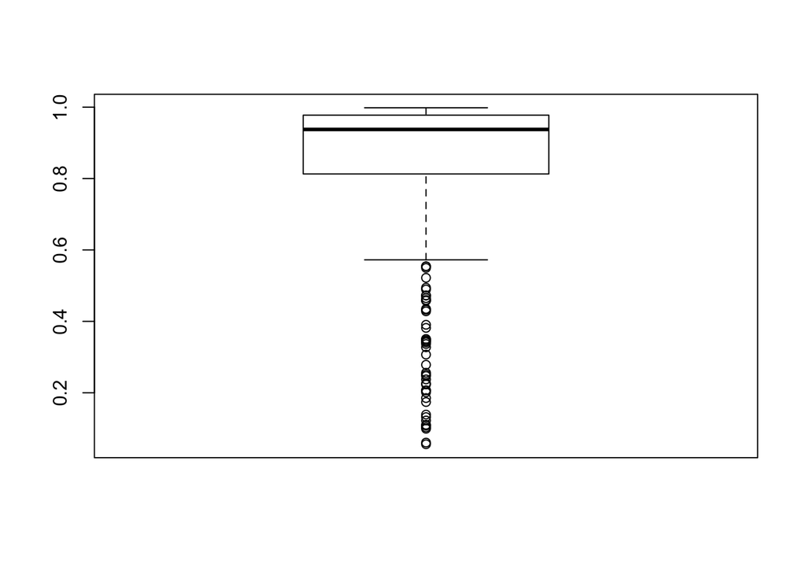

```r
boxplot(theta)
```

다음으로는 시행에서 찾아낸 첫번째 Eigenvector와 참 공분산행렬의 첫번째 Eigenvector를 내적하여 절대값 한것을 Boxplot으로 나타낸 것이다. 1에 가까운 지점에 모여있는것을 알 수 있다.

# 예제 4.15

책 예제 4.15에 나와있는 lumber stiffness data를 가지고 Standardized measurements와 Square of the distance를 직접 구해보면 다음과 같다.

```r
xbar<-colMeans(X)
var<-cov(X)
Xbarmat<-matrix(rep(xbar,30),nrow=30,ncol=4,byrow=TRUE)
t(t(X-Xbarmat)/sqrt(diag(var)))
```

```
##                x1         x2          x3          x4
##  [1,] -0.05261755 -0.3092634  0.17107644  0.16426945
##  [2,]  1.52898605  0.9367877  1.90602908  1.46211166
##  [3,]  0.65510390 -0.1554687  1.00886726  1.53954854
##  [4,] -0.80341770 -0.3845914 -1.31649701 -0.59461204
##  [5,]  0.21508578  0.5224835  0.34589106  0.48950437
##  [6,] -0.59725537 -0.1178047 -0.23132702 -0.55434486
##  [7,]  0.11354314 -0.2025487 -0.78545638 -0.16716042
##  [8,]  0.60894816  0.2211714  0.68562513  0.46162709
##  [9,]  3.31367493  3.2782337  2.97800552  2.65154223
## [10,] -0.49571272 -0.4693354 -0.41273841 -0.67204892
## [11,] -0.60340947 -0.4975834  0.02924572 -0.17955033
## [12,]  0.43047927  0.4942355  0.38877012  0.53596650
## [13,] -0.20339299  0.2870835  0.28322167  0.04966286
## [14,] -0.12031265 -0.2025487 -0.05321401 -0.14547810
```

[output cut: 16 more lines]

```r
dsq<-rep(0,30)
dsq<-as.matrix(X-Xbarmat)%*%solve(var)%*%t(X-Xbarmat)
diag(dsq)
```

```
##  [1]  0.6000129  5.4770196  7.6166439  5.2076098  1.3980776  2.2191409
##  [7]  4.9883498  1.4876570 12.2647550  0.7665400  1.9307771  0.4635159
## [13]  2.6959024  0.1295714  1.0792484 16.8474070  3.5018290  3.9900603
## [19]  1.3632124  1.4649908  9.8980384  5.0557446  0.7962096  2.5385575
## [25]  4.5767867  3.3979804  2.3816050  2.9951752  6.2837628  2.5838186
```

그리고 주어진 Scatter plot을 그려보면 다음과 같다.

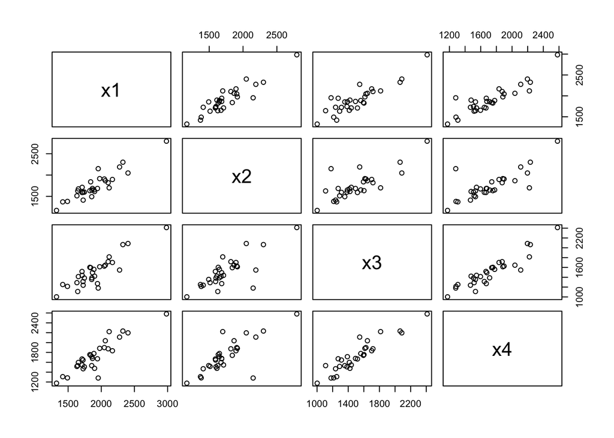

```r
library(car)
pairs(~x1+x2+x3+x4,data=X)
```

# 화살촉 행렬의 역행렬

여기서는 Review시간에 확인했던 분할행렬의 역행렬을 구하는 방법의 효과를 확인해보도록 한다. 얼마나 좋은 효율을 내는지 확인하기 위해 다음과 같은 화살촉 행렬을 생각한다.

$H = \left[ {\begin{array}{cc} A_{11} & A_{12} \\ A_{21} & D \end{array} } \right]$ 여기서 $A_{11} = 10 I_{10} + J_{10}, A_{12} = J_{10,n−10} , D = 10 I_{n-10}$로 설정되었다. 행렬 $I_k$는 $k \times k$ 단위행 렬이고, $J_{l,m}$은 $l \times m$차원 행렬로 모든 원소가 1인 행렬이다.

이 행렬에 대해서, $H$에 대한 역행렬을 직접 구한 방법과 분할행렬의 역행렬 공식

$H^{-1} = \left[ {\begin{array}{cc} A_{11}^{-1}+A_{11}^{-1}A_{12}QA_{21}A_{11}^{-1} & -A_{11}^{-1}A_{12}Q \\ -QA_{21}A_{11}^{-1} & Q \end{array}} \right]$ ($Q=D^{-1}+D^{-1}A_{21}(A_{11}-A_{12}D^{-1}A_{21})A_{12}D^{-1}$) 을 이용해서 구한 방법 두 가지의 속도를 비교해보면 다음과 같다.

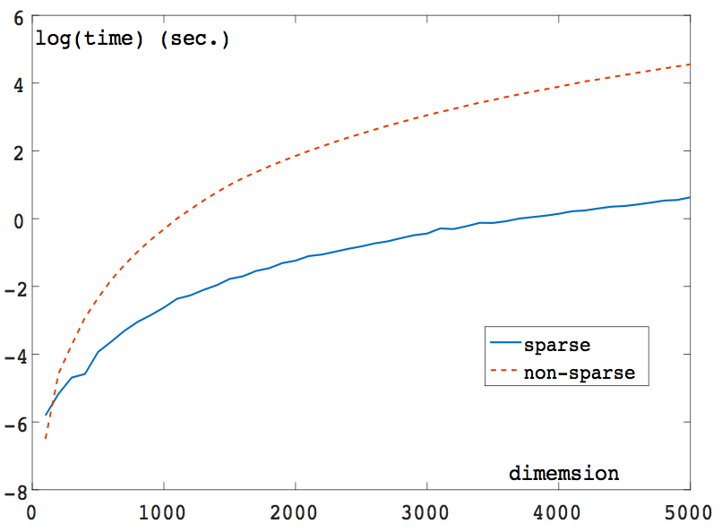

이처럼 행렬의 차원이 큰 경우에 특별한 모양의 행렬 (여기서는 화살촉 행렬이지만 다른 모양의 행렬이 될 수도 있음)은, 분할행렬의 역행렬을 이용하면 훨씬 더 빠르게 역행렬을 계산할 수도 있음을 알 수 있다.